# Project Regspas

# Packages

```r
library(spdep)        # Analisis data spasial: spatial autocorrelation, spatial regression
```

```r
library(sp)           # Struktur data untuk manipulasi data spasial (poligon, titik, dll)
library(sf)           # Mengelola data spasial dengan standar Simple Features (sf)
library(readxl)       # Membaca file Excel (format .xls dan .xlsx)
library(openxlsx)     # Membuat, membaca, dan menulis file Excel (lebih cepat dari readxl)
library(corrplot)     # Membuat visualisasi korelasi dalam bentuk plot
library(DescTools)    # Kumpulan fungsi statistik deskriptif dan inferensial
library(nortest)      # Melakukan uji normalitas (Anderson-Darling, Lilliefors, dll)
library(car)          # Fungsi regresi linear dan diagnostik model (vif, durbinWatsonTest, dll)
library(spatialreg)   # Estimasi model regresi spasial (SAR, SEM, SLM)
library(lmtest)       # Fungsi untuk menguji model regresi (heteroskedastisitas, serial correlation)
library(dplyr)        # Manipulasi data seperti filter, select, mutate, dan summarise
library(RColorBrewer) # Skema palet warna yang dapat digunakan dalam visualisasi
library(ggplot2)      # Membuat grafik statistik dengan pendekatan Grammar of Graphics
```

# Import Data

Data yang digunakan adalah data sosial ekonomi dari kab/kota di Provinsi Sumatera Utara. Peubah - peubah yang digunakan adalah Y = Persentase penduduk miskin X1 = Rata - rata lama sekolah X2 = Pengeluaran per kapita X3 = Umur harapan hidup X4 = Harapan lama sekolah

## Data

```r
data <- read_excel("C:/Users/Shabrina/Storage/University/Semester 5/Regresi Spasial/UAS/Sumut.xlsx")
head(data)
```

```
## # A tibble: 6 × 8
##   `NAMA KABUPATEN`     PPM   RLS   PPK   UHH   HLS   lat  long
##   <chr>              <dbl> <dbl> <dbl> <dbl> <dbl> <dbl> <dbl>
## 1 Asahan              8.21  8.83 11795  73.4  12.6  2.82  99.6
## 2 Batu Bara          11.4   8.5  10933  72.6  13.1  3.17  99.5
## 3 Dairi               7.47  9.88 10969  74.1  13.3  2.87  98.3
## 4 Deli Serdang        3.44 10.3  12890  73.6  13.4  3.42  98.7
## 5 Humbang Hasundutan  8.69 10.0   8476  74.1  13.3  2.20  98.6
## 6 Karo                7.98 10.0  12779  74.2  13.2  3.11  98.3
```

## Dimensi Data

```r
dim(data)
```

```
## [1] 33  8
```

Data terdiri dari 33 kab/kota di Provinsi Sumatera Utara

## Peta Kab/Kota

Berikut ini adalah peta Provinsi Sumatera Utara:

```r
peta <- st_read("C:/Users/Shabrina/Storage/University/Semester 5/Regresi Spasial/UAS/RBI_50K_2023_Sumatera Utara.x26272")
# Filter data untuk menghapus entri dengan NAMOBJ "Sumatera Utara"
peta <- subset(peta, NAMOBJ != "Sumatera Utara")
```

```r
peta
```

```
## Simple feature collection with 33 features and 25 fields
## Geometry type: MULTIPOLYGON
## Dimension:     XY, XYZ
## Bounding box:  xmin: 97.05747 ymin: -0.6387974 xmax: 100.4345 ymax: 4.302547
## z_range:       zmin: 0 zmax: 0
## Geodetic CRS:  WGS 84
## First 10 features:
##                   NAMOBJ      FCODE REMARK                   METADATA SRS_ID
## 1                 Asahan BA03050040   <NA> TASWIL5000020230907KABKOTA   4326
## 2              Batu Bara BA03050040   <NA> TASWIL5000020230907KABKOTA   4326
## 3                  Dairi BA03050040 <Null> TASWIL5000020230907KABKOTA   4326
## 4           Deli Serdang BA03050040   <NA> TASWIL5000020230907KABKOTA   4326
## 5     Humbang Hasundutan BA03050040 <Null> TASWIL5000020230907KABKOTA   4326
## 6                   Karo BA03050040 <Null> TASWIL5000020230907KABKOTA   4326
## 7            Kota Binjai BA03050040   <NA> TASWIL5000020230907KABKOTA   4326
```

[output cut: 36 more lines]

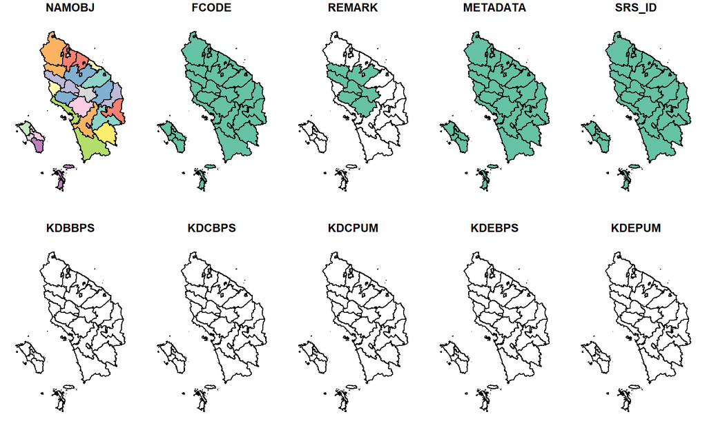

```r
plot(peta, main = "Peta Provinsi Sumatera Utara")
```

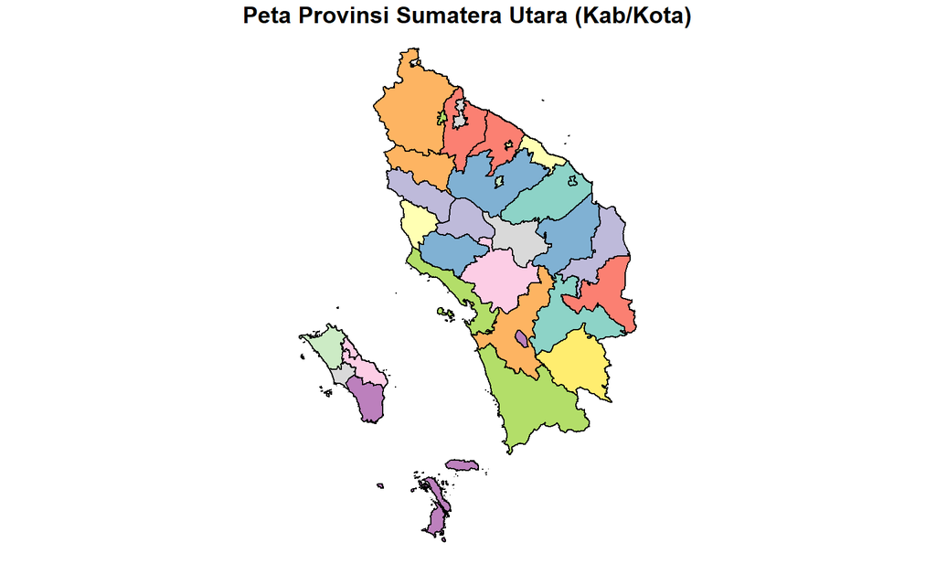

```r
plot(peta[1], main = "Peta Provinsi Sumatera Utara (Kab/Kota)")
```

# Eksplorasi Data

## Cek Missing Value

```r
data[!complete.cases(data),]
```

```
## # A tibble: 0 × 8
## # ℹ 8 variables: NAMA KABUPATEN <chr>, PPM <dbl>, RLS <dbl>, PPK <dbl>,
## #   UHH <dbl>, HLS <dbl>, lat <dbl>, long <dbl>
```

Hasil pengecekan missing value menunjukkan bahwa tidak terdapat missing value pada data.

## Ringkasan Staristik Deskriptif

```r
summary(data)
```

```
##  NAMA KABUPATEN          PPM              RLS              PPK
##  Length:33          Min.   : 3.440   Min.   : 6.140   Min.   : 6382
##  Class :character   1st Qu.: 7.870   1st Qu.: 8.840   1st Qu.: 9395
##  Mode  :character   Median : 8.540   Median : 9.510   Median :11632
##                     Mean   : 9.925   Mean   : 9.387   Mean   :10911
##                     3rd Qu.:11.420   3rd Qu.:10.090   3rd Qu.:12115
##                     Max.   :22.810   Max.   :11.620   Max.   :15674
##       UHH             HLS             lat              long
##  Min.   :71.52   Min.   :12.64   Min.   :0.7086   Min.   : 97.39
##  1st Qu.:72.30   1st Qu.:13.25   1st Qu.:1.5759   1st Qu.: 98.31
##  Median :73.65   Median :13.42   Median :2.3466   Median : 99.06
##  Mean   :73.25   Mean   :13.48   Mean   :2.2944   Mean   : 98.89
##  3rd Qu.:74.10   3rd Qu.:13.70   3rd Qu.:2.9782   3rd Qu.: 99.37
##  Max.   :74.76   Max.   :14.78   Max.   :3.8654   Max.   :100.17
```

```r
# Menunjukkan kab/kota dengan Y/PPM tertinggi
wilayah_max <- data %>%
  arrange(desc(data$PPM)) %>%
  slice(1)

print(paste("Kabupaten/kota dengan Y tertinggi adalah", wilayah_max$`NAMA KABUPATEN`))
```

```
## [1] "Kabupaten/kota dengan Y tertinggi adalah Nias Barat"
```

```r
# Menunjukkan kab/kota dengan Y/PPM terendah
wilayah_min <- data %>%
  arrange(data$PPM) %>%
  slice(1)

print(paste("Kabupaten/kota dengan Y terendah adalah", wilayah_min$`NAMA KABUPATEN`))
```

```
## [1] "Kabupaten/kota dengan Y terendah adalah Deli Serdang"
```

Berdasarkan output di atas diketahui bahwa Y/PPM tertinggi di Provinsi Sumatera Utara adalah Nias Barat sebesar 22.81, sedangkan Y/PPM terendah adalah Deli Serdang sebesar 3.44. Rata-rata Y/PPM kab/kota di Provinsi Sumatera Utara adalah 9.925.

## Boxplot

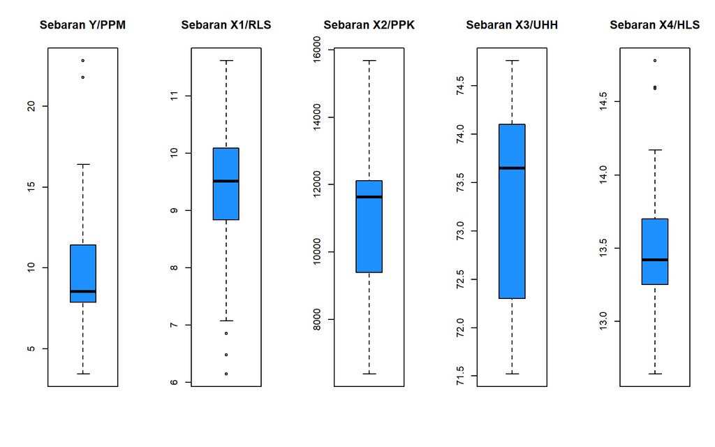

```r
par(mfrow=c(1,5))
boxplot(data$PPM,main = "Sebaran Y/PPM", col="dodgerblue")
boxplot(data$RLS,main = "Sebaran X1/RLS", col="dodgerblue")
boxplot(data$PPK,main = "Sebaran X2/PPK", col="dodgerblue")
boxplot(data$UHH,main = "Sebaran X3/UHH", col="dodgerblue")
boxplot(data$HLS,main = "Sebaran X4/HLS", col="dodgerblue")
```

Berdasarkan boxplot di atas dapat diketahui bahwa pada PPM, RLS, dan HLS terdapat pencilan.

## Hubungan antara Peubah Respon dan Peubah Penjelas

Scatter plot ini untuk melihat pola hubungan Y dengan masing-masing peubah X1, X2, X3, dan X4 serta pola hubungan antar peubah X.

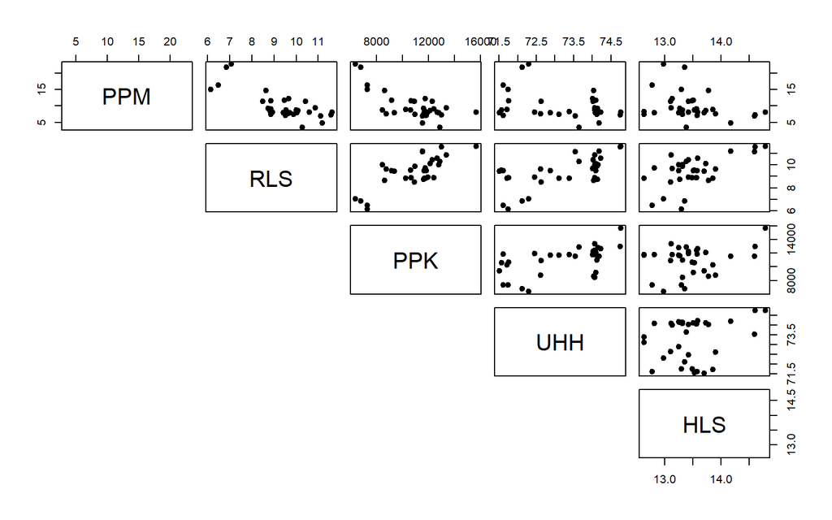

```r
pairs(data[,2:6], pch = 19, lower.panel = NULL)
```

Berdasarkan scatter plot di atas, hubungan antara peubah independent dengan dependent serta antar peubah independent kurang terlihat jelas polanya.

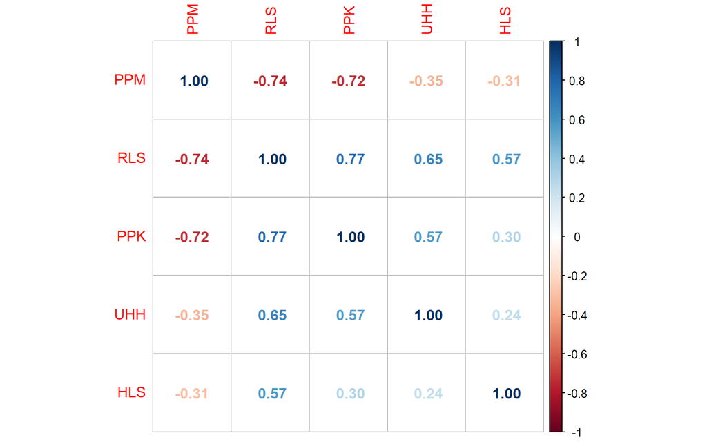

```r
corrplot(cor(data[,2:6]), method = "number")
```

Berdasarkan scatter plot ini, diperoleh nilai korelasi antara PPM atau peubah dependent dengan peubah independent yaitu ada hubungan negatif. Lalu, hubungan antar peubah independent bernilai positif.

```r
cor(data[,2:6])
```

```
##            PPM        RLS        PPK        UHH        HLS
## PPM  1.0000000 -0.7441833 -0.7214875 -0.3481624 -0.3068192
## RLS -0.7441833  1.0000000  0.7722856  0.6529525  0.5728017
## PPK -0.7214875  0.7722856  1.0000000  0.5691507  0.2973662
## UHH -0.3481624  0.6529525  0.5691507  1.0000000  0.2446364
## HLS -0.3068192  0.5728017  0.2973662  0.2446364  1.0000000
```

# Sebaran Spasial Data

```r
# Gabungkan Data
combined_data <- peta %>%
  left_join(data, by = c("NAMOBJ" = "NAMA KABUPATEN"))
combined_data
```

```
## Simple feature collection with 33 features and 32 fields
## Geometry type: MULTIPOLYGON
## Dimension:     XY, XYZ
## Bounding box:  xmin: 97.05747 ymin: -0.6387974 xmax: 100.4345 ymax: 4.302547
## z_range:       zmin: 0 zmax: 0
## Geodetic CRS:  WGS 84
## First 10 features:
##                   NAMOBJ      FCODE REMARK                   METADATA SRS_ID
## 1                 Asahan BA03050040   <NA> TASWIL5000020230907KABKOTA   4326
## 2              Batu Bara BA03050040   <NA> TASWIL5000020230907KABKOTA   4326
## 3                  Dairi BA03050040 <Null> TASWIL5000020230907KABKOTA   4326
## 4           Deli Serdang BA03050040   <NA> TASWIL5000020230907KABKOTA   4326
## 5     Humbang Hasundutan BA03050040 <Null> TASWIL5000020230907KABKOTA   4326
## 6                   Karo BA03050040 <Null> TASWIL5000020230907KABKOTA   4326
## 7            Kota Binjai BA03050040   <NA> TASWIL5000020230907KABKOTA   4326
```

[output cut: 47 more lines]

```r
sf::st_is_valid(combined_data)
```

```
## st_as_s2(): dropping Z and/or M coordinate
```

```
##  [1]  TRUE  TRUE  TRUE  TRUE  TRUE  TRUE  TRUE  TRUE FALSE  TRUE  TRUE  TRUE
## [13]  TRUE  TRUE  TRUE  TRUE  TRUE  TRUE  TRUE  TRUE  TRUE  TRUE  TRUE  TRUE
## [25]  TRUE  TRUE  TRUE  TRUE  TRUE  TRUE  TRUE  TRUE  TRUE
```

```r
library(sf)

# Memeriksa poligon tidak valid
invalid_rows <- which(!st_is_valid(combined_data))
```

```
## st_as_s2(): dropping Z and/or M coordinate
```

```r
# Menampilkan informasi tentang baris tidak valid
combined_data[invalid_rows, ]
```

```
## Simple feature collection with 1 feature and 32 fields
## Geometry type: MULTIPOLYGON
## Dimension:     XYZ
## Bounding box:  xmin: 98.59263 ymin: 3.479939 xmax: 98.74721 ymax: 3.801318
## z_range:       zmin: 0 zmax: 0
## Geodetic CRS:  WGS 84
##       NAMOBJ      FCODE REMARK                   METADATA SRS_ID KDBBPS KDCBPS
## 9 Kota Medan BA03050040   <NA> TASWIL5000020230907KABKOTA   4326   <NA>   <NA>
##   KDCPUM KDEBPS KDEPUM KDPBPS KDPKAB KDPPUM   LUASWH TIPADM WADMKC WADMKD
## 9   <NA>   <NA>   <NA>   <NA>  12.71     12 279.2904      5   <NA>   <NA>
##       WADMKK         WADMPR WIADKC WIADKK WIADPR WIADKD SHAPE_Leng SHAPE_Area
## 9 Kota Medan Sumatera Utara   <NA>   <NA>   <NA>      0   1.718649  0.0227342
##   PPM   RLS   PPK   UHH   HLS    lat    long                       geometry
## 9   8 11.62 15674 74.76 14.78 3.5952 98.6722 MULTIPOLYGON Z (((98.74528 ...
```

```r
# Memperbaiki geometri yang tidak valid
combined_data <- st_make_valid(combined_data)
```

## Sebaran Spasial Y/PPM

```r
library(tmap)
```

```r
# Mengatur mode peta
tmap_mode("plot")  # Ganti menjadi "view" jika Anda ingin peta interaktif
```

```
## tmap mode set to plotting
```

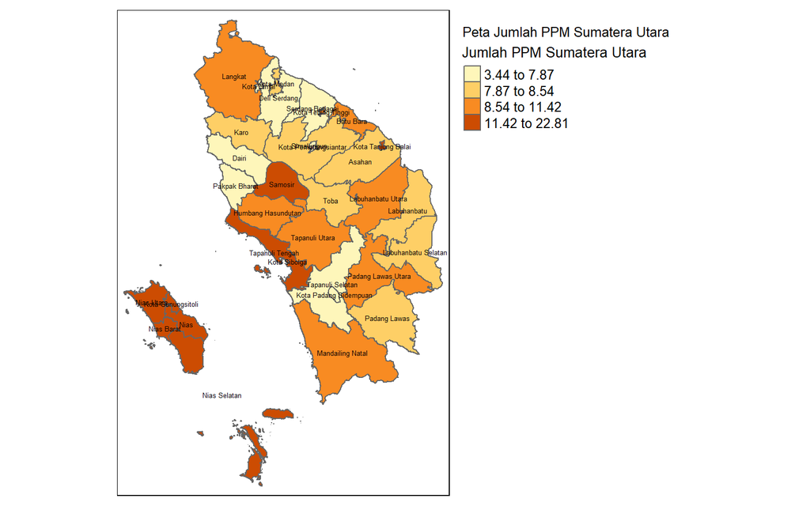

```r
# Membuat peta dengan jumlah PPM dengan label nama kabupaten/kota
tm_shape(combined_data) +
  tm_polygons("PPM", style = "quantile", n = 4,
              title = "Jumlah PPM Sumatera Utara") +
  tm_text("NAMOBJ", size = 0.4, col = "black") +  # Tambahkan nama kabupaten/kota
  tm_layout(title = "Peta Jumlah PPM Sumatera Utara",
            legend.outside = TRUE,
            legend.title.size = 1,
            legend.text.size = 0.8)
```

## Sebaran Spasial X1/RLS

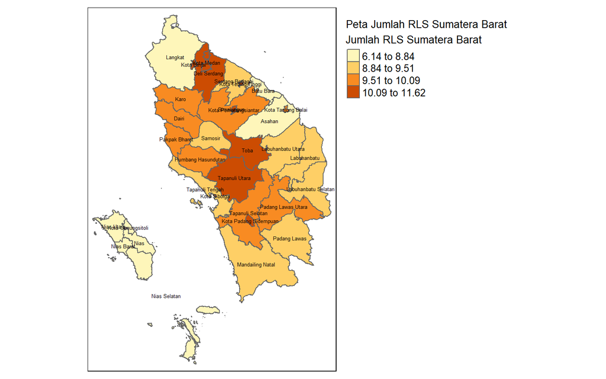

```r
# Membuat peta dengan jumlah RLS dengan label nama kabupaten/kota
tm_shape(combined_data) +
  tm_polygons("RLS", style = "quantile", n = 4,
              title = "Jumlah RLS Sumatera Barat") +
  tm_text("NAMOBJ", size = 0.4, col = "black") +  # Tambahkan nama kabupaten/kota
  tm_layout(title = "Peta Jumlah RLS Sumatera Barat",
            legend.outside = TRUE,
            legend.title.size = 1,
            legend.text.size = 0.8)
```

## Sebaran Spasial X2/PPK

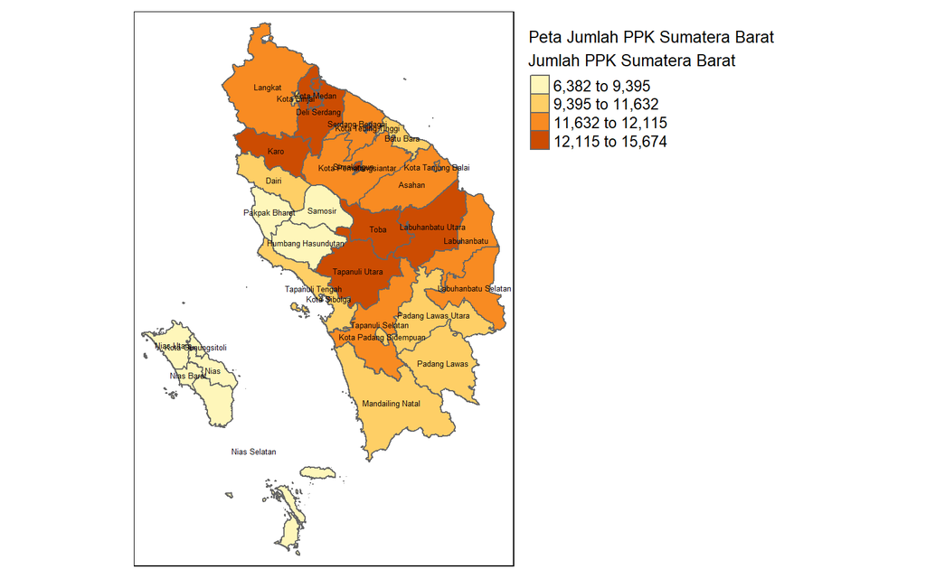

```r
# Membuat peta dengan jumlah PPK dengan label nama kabupaten/kota
tm_shape(combined_data) +
  tm_polygons("PPK", style = "quantile", n = 4,
              title = "Jumlah PPK Sumatera Barat") +
  tm_text("NAMOBJ", size = 0.4, col = "black") +  # Tambahkan nama kabupaten/kota
  tm_layout(title = "Peta Jumlah PPK Sumatera Barat",
            legend.outside = TRUE,
            legend.title.size = 1,
            legend.text.size = 0.8)
```

## Sebaran Spasial X3/UHH

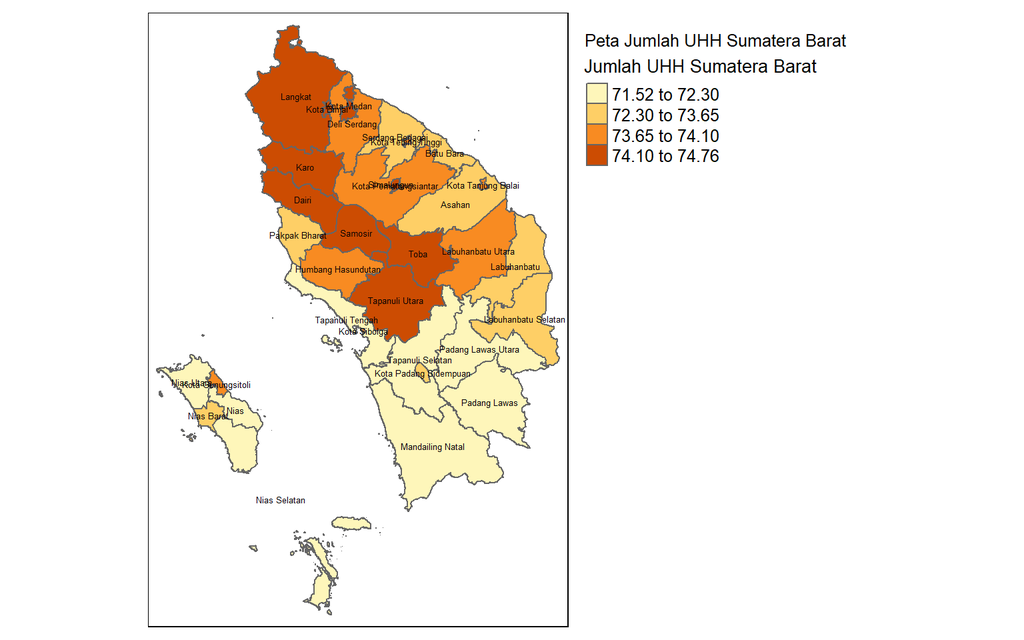

```r
# Membuat peta dengan jumlah UHH dengan label nama kabupaten/kota
tm_shape(combined_data) +
  tm_polygons("UHH", style = "quantile", n = 4,
              title = "Jumlah UHH Sumatera Barat") +
  tm_text("NAMOBJ", size = 0.4, col = "black") +  # Tambahkan nama kabupaten/kota
  tm_layout(title = "Peta Jumlah UHH Sumatera Barat",
            legend.outside = TRUE,
            legend.title.size = 1,
            legend.text.size = 0.8)
```

## Sebaran Spasial X4/HLS

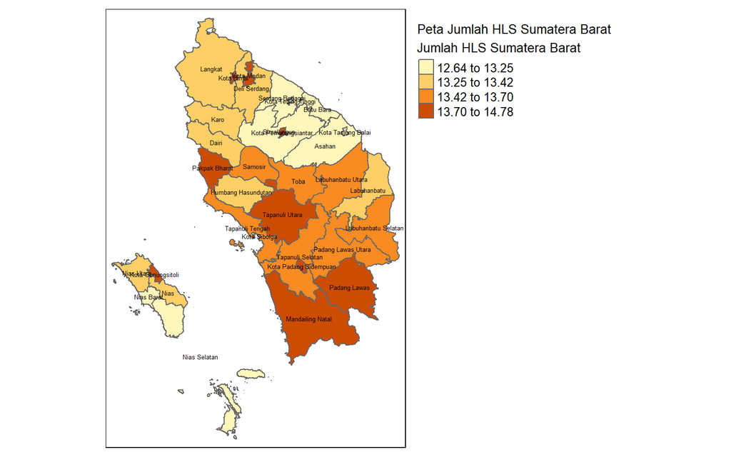

```r
# Membuat peta dengan jumlah HLS dengan label nama kabupaten/kota
tm_shape(combined_data) +
  tm_polygons("HLS", style = "quantile", n = 4,
              title = "Jumlah HLS Sumatera Barat") +
  tm_text("NAMOBJ", size = 0.4, col = "black") +  # Tambahkan nama kabupaten/kota
  tm_layout(title = "Peta Jumlah HLS Sumatera Barat",
            legend.outside = TRUE,
            legend.title.size = 1,
            legend.text.size = 0.8)
```

# Matriks Pembobot Spasial

Matriks pembobot spasial dapat berdasarkan aspek ketetanggaan dan aspek jarak. Matriks ketetanggaan yang dicobakan dalam analisis ini yaitu rook contiguity dan queen contiguity sedangkan berdasarkan aspek jarak digunakan k-nearest neighbor (KNN), radial distance weight (RDW), inverse distance weight (IDW), dan exponential distance weight (IDW).

## Matriks Pembobot Berdasarkan Ketetanggaan

### Queen Contiguity

Matriks pembobot spasial queen contiguity lebih luas daripada rook contiguity karena wilayah-wilayah dianggap bertetangga jika mereka berbagi sisi atau titik sudut.

Karakteristik:

Dua poligon dianggap bertetangga jika mereka berbagi batas (baik sisi maupun titik sudut).

Jika dua wilayah memiliki titik atau sisi yang bersinggungan, maka elemen matriks pembobot diberi nilai 1.

```r
# Memvalidasi geometri dalam objek sf
peta <- st_make_valid(peta)
# Konversi objek sf ke objek sp
sp.peta <- as(peta, "Spatial")

# Mengakses slot polygons dari objek sp
sp.polygons <- SpatialPolygons(sp.peta@polygons)
queen <- poly2nb(sp.peta, queen = T)
```

```r
queen
```

```
## Neighbour list object:
## Number of regions: 33
## Number of nonzero links: 118
## Percentage nonzero weights: 10.83563
## Average number of links: 3.575758
## 2 disjoint connected subgraphs
```

```r
W.queen <- nb2listw(queen, style='W',zero.policy=TRUE)
qc = moran.test(data$PPM, W.queen,randomisation=T,
alternative="greater", zero.policy = TRUE)
qc
```

```
##
##  Moran I test under randomisation
##
## data:  data$PPM
## weights: W.queen
##
## Moran I statistic standard deviate = 6.2127, p-value = 2.604e-10
## alternative hypothesis: greater
## sample estimates:
## Moran I statistic       Expectation          Variance
##        0.76773982       -0.03125000        0.01653951
```

```r
moran.mc(data$PPM, listw = W.queen, zero.policy = TRUE, nsim = 99)
```

```
##
##  Monte-Carlo simulation of Moran I
##
## data:  data$PPM
## weights: W.queen
## number of simulations + 1: 100
##
## statistic = 0.76774, observed rank = 100, p-value = 0.01
## alternative hypothesis: greater
```

### Rook Contiguity

Matriks pembobot spasial rook contiguity didasarkan pada konsep bahwa dua wilayah dianggap bertetangga jika mereka berbagi sisi batas.

Karakteristik:

Dua poligon dianggap bertetangga jika mereka memiliki batas yang bersinggungan di sepanjang sisi yang sama (tidak hanya di titik sudut).

Jika dua wilayah bertetangga, nilai elemen matriks pembobot adalah 1; jika tidak, maka nilai elemen tersebut adalah 0.

```r
rook <- poly2nb(sp.peta, queen = F)
```

```r
rook
```

```
## Neighbour list object:
## Number of regions: 33
## Number of nonzero links: 118
## Percentage nonzero weights: 10.83563
## Average number of links: 3.575758
## 2 disjoint connected subgraphs
```

```r
W.rook <- nb2listw(rook, style='W',zero.policy=TRUE)
rc = moran.test(data$PPM, W.rook,randomisation=T,
alternative="greater", zero.policy = TRUE)
rc
```

```
##
##  Moran I test under randomisation
##
## data:  data$PPM
## weights: W.rook
##
## Moran I statistic standard deviate = 6.2127, p-value = 2.604e-10
## alternative hypothesis: greater
## sample estimates:
## Moran I statistic       Expectation          Variance
##        0.76773982       -0.03125000        0.01653951
```

```r
moran.mc(data$PPM, listw = W.rook, zero.policy = TRUE, nsim = 99)
```

```
##
##  Monte-Carlo simulation of Moran I
##
## data:  data$PPM
## weights: W.rook
## number of simulations + 1: 100
##
## statistic = 0.76774, observed rank = 100, p-value = 0.01
## alternative hypothesis: greater
```

## Matriks Pembobot Berdasarkan Jarak

```r
# Menghitung centroid dari setiap unit spasial
centroids <- st_centroid(peta)
# Ekstrak koordinat centroid
longlat <- st_coordinates(centroids)

# Tambahkan koordinat long dan lat ke objek peta
peta$long <- longlat[, 1]  # Kolom X (long)
peta$lat  <- longlat[, 2]  # Kolom Y (lat)
```

```r
coords <- peta[c("long","lat")]
#class(coords)
koord <- as.data.frame(coords)
jarak<-dist(longlat, method = "euclidean")
m.jarak<-as.matrix(jarak)
```

### K-Nearest Neighbor

Matriks bobot k-nearest neighbor menentukan tetangga berdasarkan sejumlah tetangga terdekat (k) yang dipilih untuk setiap titik atau wilayah.

Karakteristik:

Untuk setiap titik/wilayah, tetangga yang dipilih adalah titik/wilayah yang paling dekat (berdasarkan jarak Euclidean atau jarak lainnya).

Nilai matriks bobot diberikan 1 jika suatu titik berada dalam k tetangga terdekat dari titik lain, dan 0 jika tidak.

Contoh: Misalkan k = 3, artinya setiap titik akan memiliki 3 tetangga terdekat. Matriks bobot akan memiliki 1 di elemen yang mewakili tetangga terdekat, dan 0 di elemen lainnya.

Digunakan 5 tetangga terdekat (k=5).

```r
# k = 5
W.knn<-knn2nb(knearneigh(longlat,k=5,longlat=TRUE))
W.knn.s <- nb2listw(W.knn,style='W')

MI.knn <- moran(data$PPM,W.knn.s,n=length(W.knn.s$neighbours),S0=Szero(W.knn.s))
mt1 = moran.test(data$PPM,W.knn.s,randomisation = T,alternative = "greater")
mt1
```

```
##
##  Moran I test under randomisation
##
## data:  data$PPM
## weights: W.knn.s
##
## Moran I statistic standard deviate = 6.9406, p-value = 1.952e-12
## alternative hypothesis: greater
## sample estimates:
## Moran I statistic       Expectation          Variance
##       0.603119698      -0.031250000       0.008353978
```

```r
# k = 3
W.knn.3 <-knn2nb(knearneigh(longlat,k=3,longlat=TRUE))
W.knn.3.s <- nb2listw(W.knn,style='W')

MI.knn.3 <- moran(data$PPM,W.knn.s,n=length(W.knn.s$neighbours),S0=Szero(W.knn.s))
mt1.3 = moran.test(data$PPM,W.knn.s,randomisation = T,alternative = "greater")
mt1.3
```

```
##
##  Moran I test under randomisation
##
## data:  data$PPM
## weights: W.knn.s
##
## Moran I statistic standard deviate = 6.9406, p-value = 1.952e-12
## alternative hypothesis: greater
## sample estimates:
## Moran I statistic       Expectation          Variance
##       0.603119698      -0.031250000       0.008353978
```

### Radial Distance Weight

Matriks bobot radial distance mendefinisikan tetangga berdasarkan jarak geografis. Setiap titik atau wilayah dianggap sebagai tetangga jika jaraknya dari titik/wilayah pusat berada dalam jarak radius tertentu.

Karakteristik:

Tetangga dipilih berdasarkan jarak dari titik pusat hingga ke titik lain dalam radius tertentu (r). Jika titik lain berada dalam radius tersebut, maka nilai dalam matriks bobot adalah 1; jika tidak, maka 0.

Jarak dihitung berdasarkan metrik spasial seperti jarak Euclidean.

Contoh: Jika radius yang ditentukan adalah 10 km, maka setiap titik atau wilayah yang berada dalam jarak 10 km dari titik pusat akan dianggap sebagai tetangga, dan bobot matriks akan diberikan 1.

Ditentukan nilai ambang dmax adalah 105 km (d=105). Nilai ini menggambarkan nilai jarak maksimum untuk menentukan dependensi spasial anatar lokasi-i terhadap lokasi-j.

```r
W.rdw <-dnearneigh(longlat,0,105,longlat=TRUE)
W.rdw.s <- nb2listw(W.rdw,style="W", zero.policy=TRUE)

MI.rdw <- moran(data$PPM,W.rdw.s,n=length(W.rdw.s$neighbours),S0=Szero(W.rdw.s))
mt2 = moran.test(data$PPM,W.rdw.s,randomisation = T,alternative = "greater")
mt2
```

```
##
##  Moran I test under randomisation
##
## data:  data$PPM
## weights: W.rdw.s
##
## Moran I statistic standard deviate = 9.5265, p-value < 2.2e-16
## alternative hypothesis: greater
## sample estimates:
## Moran I statistic       Expectation          Variance
##       0.712965482      -0.031250000       0.006102799
```

## Inverse Distance Weight

Matriks pembobot Inverse Distance Weight (IDW) menentukan bobot berdasarkan kebalikan dari jarak antar titik atau wilayah. Semakin dekat dua titik, semakin besar bobot yang diberikan.

Ditentukan nilai alpha=1 dan alpha=2

```r
alpha1=1
W.idw <-1/(m.jarak^alpha1)
diag(W.idw)<-0
rtot<-rowSums(W.idw,na.rm=TRUE)
W.idw.sd<-W.idw/rtot #row-normalized
W.idw.s = mat2listw(W.idw.sd,style='W')

MI.idw <- moran(data$PPM,W.idw.s,n=length(W.idw.s$neighbours),S0=Szero(W.idw.s))
mt3 = moran.test(data$PPM,W.idw.s,randomisation = T,alternative = "greater")
mt3
```

```
##
##  Moran I test under randomisation
##
## data:  data$PPM
## weights: W.idw.s
##
## Moran I statistic standard deviate = 7.2421, p-value = 2.209e-13
## alternative hypothesis: greater
## sample estimates:
## Moran I statistic       Expectation          Variance
##       0.276568851      -0.031250000       0.001806597
```

```r
alpha2=2
W.idw2<-1/(m.jarak^alpha2)
diag(W.idw2)<-0
rtot<-rowSums(W.idw2,na.rm=TRUE)
W.idw2.sd<-W.idw2/rtot #row-normalized
W.idw2.s = mat2listw(W.idw2.sd,style='W')

MI.idw2 <- moran(data$PPM,W.idw2.s,n=length(W.idw2.s$neighbours),S0=Szero(W.idw2.s))
mt4 = moran.test(data$PPM,W.idw2.s,randomisation = T,alternative = "greater")
mt4
```

```
##
##  Moran I test under randomisation
##
## data:  data$PPM
## weights: W.idw2.s
##
## Moran I statistic standard deviate = 5.8423, p-value = 2.574e-09
## alternative hypothesis: greater
## sample estimates:
## Moran I statistic       Expectation          Variance
##        0.58469819       -0.03125000        0.01111513
```

## Exponential Distance Weight

Matriks exponential distance weight memberikan bobot yang menurun secara eksponensial seiring dengan peningkatan jarak antar unit spasial. Ini mirip dengan inverse distance weight, tetapi penurunan bobot terhadap jarak lebih tajam.

Ditentukan alpha=1 dan alpha=2

```r
alpha=1
W.edw<-exp((-alpha)*m.jarak)
diag(W.edw)<-0
rtot<-rowSums(W.edw,na.rm=TRUE)
W.edw.sd<-W.edw/rtot #row-normalized
W.edw.s = mat2listw(W.edw.sd,style='W')

MI.edw <- moran(data$PPM,W.edw.s,n=length(W.edw.s$neighbours),S0=Szero(W.edw.s))
mt5 = moran.test(data$PPM,W.edw.s,randomisation = T,alternative = "greater")
mt5
```

```
##
##  Moran I test under randomisation
##
## data:  data$PPM
## weights: W.edw.s
##
## Moran I statistic standard deviate = 10.703, p-value < 2.2e-16
## alternative hypothesis: greater
## sample estimates:
## Moran I statistic       Expectation          Variance
##      0.2656130663     -0.0312500000      0.0007692685
```

```r
alpha2=2
W.edw2<-exp((-alpha2)*m.jarak)
diag(W.edw2)<-0
rtot<-rowSums(W.edw2,na.rm=TRUE)
W.edw2.sd<-W.edw2/rtot #row-normalized
W.edw2.s = mat2listw(W.edw2.sd,style='W')
MI.edw2 <- moran(data$PPM,W.edw2.s,n=length(W.edw2.s$neighbours),S0=Szero(W.edw2.s))
mt6 = moran.test(data$PPM,W.edw2.s,randomisation = T,alternative = "greater")
mt6
```

```
##
##  Moran I test under randomisation
##
## data:  data$PPM
## weights: W.edw2.s
##
## Moran I statistic standard deviate = 10.391, p-value < 2.2e-16
## alternative hypothesis: greater
## sample estimates:
## Moran I statistic       Expectation          Variance
##       0.537741479      -0.031250000       0.002998588
```

## Pemilihan Matriks Pembobot Terbaik

Matriks pembobot spasial yang dipilih yaitu matriks yang menghasilkan nilai autokorelasi spasial yang tertinggi. Pemilihan matriks bobot juga dapat didasarkan pada matriks bobot dengan nilai indeks moran yang signifikan pada taraf 5%.

```r
MatriksBobot <- c("K-Nearest Neighbor (k=5)",
                  "Radial Distance Weight (dmax=105)",
                  "Invers Distance Weight (alpha=1)",
                  "Invers Distance Weight (alpha=2)",
                  "Exponential Distance Weight (alpha=1)",
                  "Exponential Distance Weight (alpha=2)",
                  "Rook Contiguity",
                  "Queen Contiguity")
IndeksMoran <- c(MI.knn$I,MI.rdw$I,MI.idw$I,MI.idw2$I,MI.edw$I,MI.edw2$I,rc$estimate[1],qc$estimate[1])
pv = c(mt1$p.value,mt2$p.value,mt3$p.value,mt4$p.value,mt5$p.value,mt6$p.value,rc$p.value,qc$p.value)
Matriks = cbind.data.frame(MatriksBobot, IndeksMoran,"p-value"=pv)
colnames(Matriks) <-c("Matriks Bobot", "Indeks Moran", "p-value")
Matriks
```

```
##                           Matriks Bobot Indeks Moran      p-value
## 1              K-Nearest Neighbor (k=5)    0.6031197 1.952469e-12
## 2     Radial Distance Weight (dmax=105)    0.7129655 8.132416e-22
## 3      Invers Distance Weight (alpha=1)    0.2765689 2.208934e-13
## 4      Invers Distance Weight (alpha=2)    0.5846982 2.573622e-09
## 5 Exponential Distance Weight (alpha=1)    0.2656131 4.911509e-27
## 6 Exponential Distance Weight (alpha=2)    0.5377415 1.365822e-25
## 7                       Rook Contiguity    0.7677398 2.604196e-10
## 8                      Queen Contiguity    0.7677398 2.604196e-10
```

```r
Matriks[Matriks$`p-value`< 0.05,]
```

```
##                           Matriks Bobot Indeks Moran      p-value
## 1              K-Nearest Neighbor (k=5)    0.6031197 1.952469e-12
## 2     Radial Distance Weight (dmax=105)    0.7129655 8.132416e-22
## 3      Invers Distance Weight (alpha=1)    0.2765689 2.208934e-13
## 4      Invers Distance Weight (alpha=2)    0.5846982 2.573622e-09
## 5 Exponential Distance Weight (alpha=1)    0.2656131 4.911509e-27
## 6 Exponential Distance Weight (alpha=2)    0.5377415 1.365822e-25
## 7                       Rook Contiguity    0.7677398 2.604196e-10
## 8                      Queen Contiguity    0.7677398 2.604196e-10
```

Berdasakan hasil di atas, Matriks bobot yang memiliki nilai Indeks Moran yang signifikan pada taraf 5% adalah k-nearest neighboor (k=5), radial distance weight (dmax=105), invers distance weight (alpha = 1 dan alpha = 2), exponential distance weight (alpha = 1 dan alpha = 2), rook contiguity, dan queen contiguity.

Matriks pembobot spasial yang memiliki Indeks Moran tertinggi adalah rook contiguity dan queen contiguity sehingga matriks tersebut dapat dipilih menjadi matriks pembobot spasial terbaik diantara matriks pembobot spasial lainnya. Selanjutnya matriks pembobot yang digunakan dalam analisis adalah queen contiguity.

# Model Regresi Klasik (OLS)

Pemodelan Ordinary Least Square dan uji asumsi multikolinearitas, autokorelasi spasial, kehomogenan ragam, kenormalan sisaan.

Matriks Bobot yang digunakan adalah queen contiguity.

## Metode OLS

```r
ols <- lm(PPM ~ RLS + PPK + UHH + HLS, data = data)
summary(ols)
```

```
##
## Call:
## lm(formula = PPM ~ RLS + PPK + UHH + HLS, data = data)
##
## Residuals:
##     Min      1Q  Median      3Q     Max
## -3.3129 -1.9354 -0.2871  0.9077  5.9370
##
## Coefficients:
##               Estimate Std. Error t value Pr(>|t|)
## (Intercept) -6.847e+01  4.381e+01  -1.563  0.12928
## RLS         -2.401e+00  7.186e-01  -3.341  0.00238 **
## PPK         -7.114e-04  3.568e-04  -1.994  0.05597 .
## UHH          1.241e+00  5.764e-01   2.153  0.04011 *
## HLS          1.321e+00  1.146e+00   1.153  0.25851
## ---
## Signif. codes:  0 '***' 0.001 '**' 0.01 '*' 0.05 '.' 0.1 ' ' 1
##
## Residual standard error: 2.578 on 28 degrees of freedom
## Multiple R-squared:  0.6691, Adjusted R-squared:  0.6219
## F-statistic: 14.16 on 4 and 28 DF,  p-value: 1.954e-06
```

```r
print(paste("Nilai AIC OLS", AIC(ols)))
```

```
## [1] "Nilai AIC OLS 162.724559457354"
```

## Model Diagnostics

### Uji Normalitas Sisaan

H0 : sisaan model menyebar normal H1 : sisaan model tidak menyebar normal

Tolak H0 jika p-value < 0.05

```r
err.ols <- residuals(ols)
ad.test(err.ols)
```

```
##
##  Anderson-Darling normality test
##
## data:  err.ols
## A = 0.80478, p-value = 0.0333
```

Karena p-value < 5%, maka tolak H0. Artinya sisaan tidak menyebar normal.

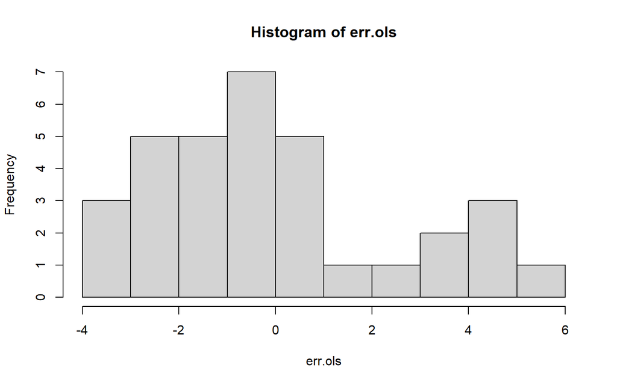

```r
hist(err.ols)
```

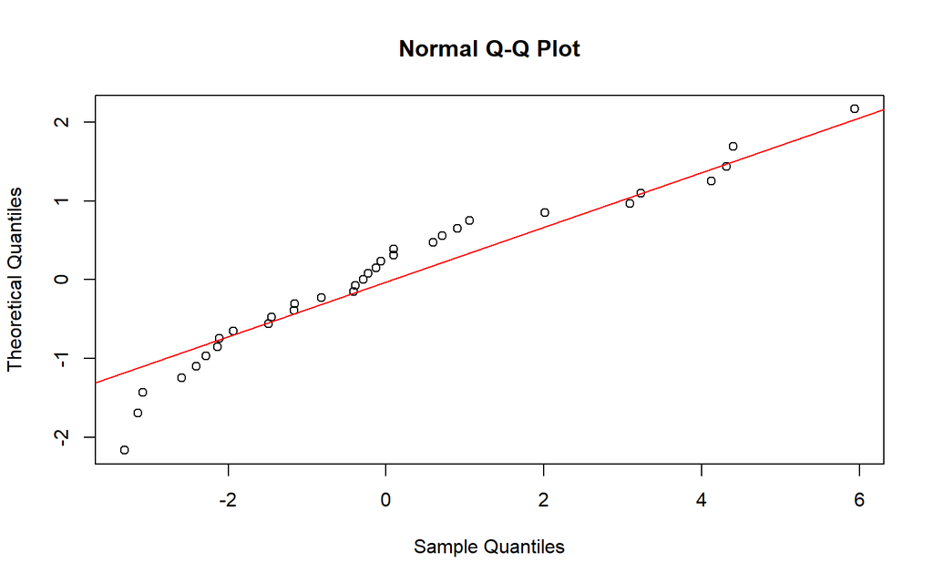

```r
qqnorm(err.ols,datax=T)
qqline(rnorm(length(err.ols),mean(err.ols),sd(err.ols)),datax=T, col="red")
```

### Uji Kehomogenan Ragam

H0 : Ragam Sisaan Homogen H1 : Ragam Sisaan Tidak Homogen

```r
lmtest::bptest(ols)
```

```
##
##  studentized Breusch-Pagan test
##
## data:  ols
## BP = 3.3554, df = 4, p-value = 0.5002
```

Karena p-value > 0.05, maka gagal tolak H0. Artinya ragam sisaan homogen

### Uji Multikolinearitas

Pada regresi linear berganda perlu diperiksa persyaratan tidak adanya multikolinearitas antar peubah penjelas agar koefisien regresi yang diperoleh dapat dikatakan valid.

Pemeriksaan multikolinearitas dapat dilakukan dengan menggunakan nilai variance inflation factor (VIF). Multikolinearitas terjadi jika nilai VIF > 5.

```r
car::vif(ols)
```

```
##      RLS      PPK      UHH      HLS
## 4.478456 2.704217 1.834623 1.667146
```

Berdasarkan perhitungan, diperoleh nilai VIF < 5 yang menunjukkan tidak terjadi multikolinearitas antar peubah penjelas.

### Uji Autokorelasi

H0 : Antargalat tidak memiliki autokorelasi H1 : Antargalat berkorelasi

```r
dwtest(ols)
```

```
##
##  Durbin-Watson test
##
## data:  ols
## DW = 1.6761, p-value = 0.1009
## alternative hypothesis: true autocorrelation is greater than 0
```

Karena p-value > 0.05, maka gagal tolak H0. Artinya, antargalat tidak berkorelasi.

# Pengujian Efek Spasial

## Efek Dependensi Spasial

Untuk menentukan model dependensi spasial yang sesuai dengan data, terlebih dahulu dilakukan uji dependensi spasial. Secara umum ada dua macam uji dependensi spasial, yaitu Indeks Moran dan Uji Pengganda Lagrange (Lagrange Multiplier Test).

## Uji Indeks Moran

H0 : Tidak ada autokorelasi spasial

H1 : Ada autokorelasi spasial

### Uji Indeks Moran pada Galat Model Regresi

```r
ww = W.queen
lm.morantest(ols, listw=ww, alternative="two.sided")
```

```
##
##  Global Moran I for regression residuals
##
## data:
## model: lm(formula = PPM ~ RLS + PPK + UHH + HLS, data = data)
## weights: ww
##
## Moran I statistic standard deviate = 0.71837, p-value = 0.4725
## alternative hypothesis: two.sided
## sample estimates:
## Observed Moran I      Expectation         Variance
##      0.001584773     -0.088268932      0.015645027
```

```r
err.ols <- residuals(ols)
merr <- moran.test(err.ols, ww,randomisation=T,
           alternative="two.sided")
merr
```

```
##
##  Moran I test under randomisation
##
## data:  err.ols
## weights: ww
##
## Moran I statistic standard deviate = 0.24288, p-value = 0.8081
## alternative hypothesis: two.sided
## sample estimates:
## Moran I statistic       Expectation          Variance
##       0.001584773      -0.031250000       0.018276611
```

### Uji Indeks Moran pada peubah Y/PPM

```r
my <- moran.test(data$PPM, ww,randomisation=T,
           alternative="two.sided")
my
```

```
##
##  Moran I test under randomisation
##
## data:  data$PPM
## weights: ww
##
## Moran I statistic standard deviate = 6.2127, p-value = 5.208e-10
## alternative hypothesis: two.sided
## sample estimates:
## Moran I statistic       Expectation          Variance
##        0.76773982       -0.03125000        0.01653951
```

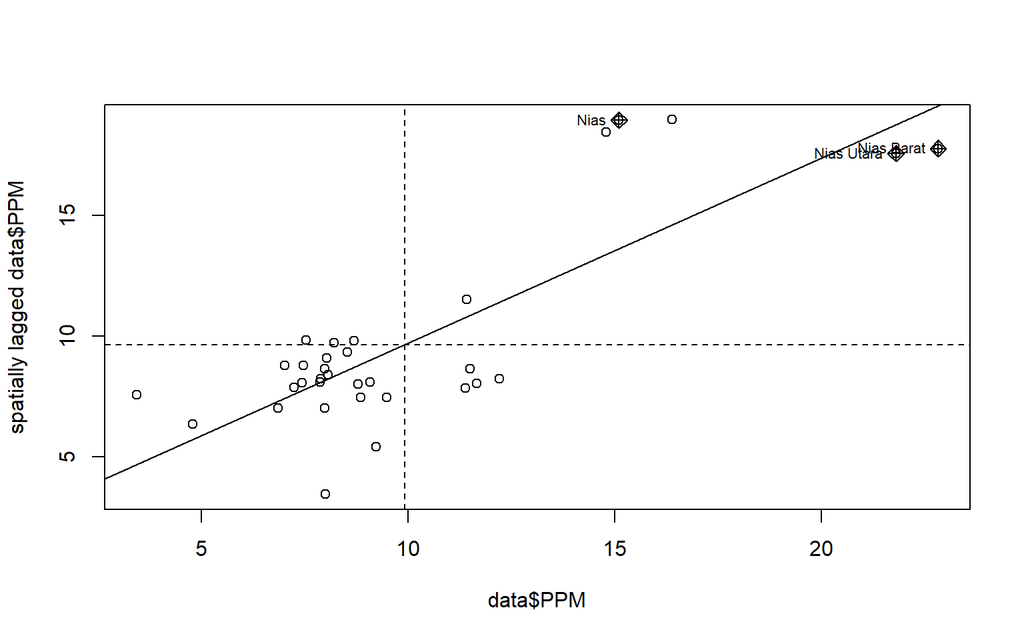

```r
moran.plot(data$PPM, ww, labels=data$`NAMA KABUPATEN`)
```

### Uji Indeks Moran pada peubah X1/RLS

```r
mx1 <- moran.test(data$RLS, ww,randomisation=T,
           alternative="two.sided")
mx1
```

```
##
##  Moran I test under randomisation
##
## data:  data$RLS
## weights: ww
##
## Moran I statistic standard deviate = 4.2142, p-value = 2.507e-05
## alternative hypothesis: two.sided
## sample estimates:
## Moran I statistic       Expectation          Variance
##        0.53376200       -0.03125000        0.01797592
```

### Uji Indeks Moran pada peubah X2/PPK

```r
mx2 <- moran.test(data$PPK, ww,randomisation=T,
           alternative="two.sided")
mx2
```

```
##
##  Moran I test under randomisation
##
## data:  data$PPK
## weights: ww
##
## Moran I statistic standard deviate = 5.4395, p-value = 5.342e-08
## alternative hypothesis: two.sided
## sample estimates:
## Moran I statistic       Expectation          Variance
##        0.70263327       -0.03125000        0.01820257
```

### Uji Indeks Moran pada peubah X3/UHH

```r
mx3 <- moran.test(data$UHH, ww,randomisation=T,
           alternative="two.sided")
mx3
```

```
##
##  Moran I test under randomisation
##
## data:  data$UHH
## weights: ww
##
## Moran I statistic standard deviate = 3.5232, p-value = 0.0004263
## alternative hypothesis: two.sided
## sample estimates:
## Moran I statistic       Expectation          Variance
##        0.45449156       -0.03125000        0.01900772
```

### Uji Indeks Moran pada peubah X4/HLS

```r
mx4 <- moran.test(data$HLS, ww,randomisation=T,
           alternative="two.sided")
mx4
```

```
##
##  Moran I test under randomisation
##
## data:  data$HLS
## weights: ww
##
## Moran I statistic standard deviate = 1.2661, p-value = 0.2055
## alternative hypothesis: two.sided
## sample estimates:
## Moran I statistic       Expectation          Variance
##         0.1375906        -0.0312500         0.0177847
```

Berikut ini adalah hasil uji autokorelasi pada peubah respon, peubah penjelas, dan sisaan regresi

```r
Peubah = c("Y", "X1", "X2","X3","X4", "Sisaan")
Indeks_Moran = c(my$estimate[1], mx1$estimate[1], mx2$estimate[1],mx3$estimate[1],mx4$estimate[1], merr$estimate[1])
p_value = c(my$p.value, mx1$p.value, mx2$p.value,mx3$p.value,mx4$p.value, merr$p.value)

df1 = cbind.data.frame(Peubah, Indeks_Moran, p_value)
colnames(df1) <- c("Peubah", "Indeks Moran", "p-value")
df1
```

```
##   Peubah Indeks Moran      p-value
## 1      Y  0.767739817 5.208393e-10
## 2     X1  0.533762002 2.506973e-05
## 3     X2  0.702633271 5.342396e-08
## 4     X3  0.454491559 4.263306e-04
## 5     X4  0.137590564 2.054923e-01
## 6 Sisaan  0.001584773 8.081008e-01
```

Berdasarkan hasil pengujian Indeks Moran di atas menunjukkan bahwa nilai indeks Moran pada peubah Y/PPM, X1/RLS, X2/PPK, dan X3/UHH model regresi memiliki nilai p-value < 0.05 maka Tolak H0 sehingga autokorelasi spasial pada peubah tersebut berpengaruh nyata. Hal ini mengindikasikan bahwa terdapat ketergantungan spasial pada peubah Y/PPM, X1/RLS, X2/PPK, dan X3/UHH regresi klasik. Terlihat pula nilai indeks moran positif pada peubah Y/PPM, X1/RLS, X2/PPK, dan X3/UHH regresi klasik yang menunjukkan adanya autokorelasi positif.

Sedangkan, nilai indeks moran pada peubah X4/HLS dan sisaan model memiliki p-value > 0.05 maka gagal tolak H0 artinya tidak terdapat autokorelasi spasial peubah X4/HLS dan sisaan model taraf nyata 5%.

Oleh karenanya, untuk mencari model yang lebih baik, kita dapat melakukan uji LM (lagrange multiplier) untuk mengidentifikasi model dependensi spasial yang dapat digunakan pada kasus ini.

## Uji Lagrange Multiplier

```r
model <- lm.LMtests(ols,listw=ww,zero.policy = TRUE, test=c("LMerr","RLMerr","LMlag","RLMlag","SARMA"))
```

```
## Please update scripts to use lm.RStests in place of lm.LMtests
```

```r
summary(model)
```

```
##  Rao's score (a.k.a Lagrange multiplier) diagnostics for spatial
##  dependence
## data:
## model: lm(formula = PPM ~ RLS + PPK + UHH + HLS, data = data)
## test weights: listw
##
##           statistic parameter  p.value
## RSerr    0.00012197         1 0.991188
## adjRSerr 4.48276650         1 0.034238 *
## RSlag    3.28066772         1 0.070100 .
## adjRSlag 7.76331225         1 0.005332 **
## SARMA    7.76343422         2 0.020615 *
## ---
## Signif. codes:  0 '***' 0.001 '**' 0.01 '*' 0.05 '.' 0.1 ' ' 1
```

Output menunjukkan bahwa hasil uji robust LM SAR, robust LM SEM, dan GSM signifikan pada taraf 5%. Berdasarkan skema tersebut, maka kita dapat mencoba kandidat model SAR, SEM, dan SARMA.

# Efek Heterogenitas Spasial

H0 : Ragam Sisaan Homogen H1 : Ragam Sisaan Tidak Homogen

```r
lmtest::bptest(ols)
```

```
##
##  studentized Breusch-Pagan test
##
## data:  ols
## BP = 3.3554, df = 4, p-value = 0.5002
```

Karena p-value > 0.05, maka Gagal Tolak H0. Artinya ragam sisaan homogen atau tidak terdapat efek heterogenitas spasial.

# Model Regresi Spasial

## Model SAR

```r
sar <- lagsarlm(PPM ~ RLS + PPK + UHH + HLS, data = data, listw = ww, zero.policy=TRUE)
summary(sar, Nagelkerke = T)
```

```
##
## Call:lagsarlm(formula = PPM ~ RLS + PPK + UHH + HLS, data = data,
##     listw = ww, zero.policy = TRUE)
##
## Residuals:
##      Min       1Q   Median       3Q      Max
## -3.68182 -1.52917 -0.59518  1.10309  5.61842
##
## Type: lag
## Coefficients: (asymptotic standard errors)
##                Estimate  Std. Error z value Pr(>|z|)
## (Intercept) -5.4235e+01  3.8386e+01 -1.4129 0.157691
## RLS         -1.8142e+00  6.5445e-01 -2.7722 0.005568
## PPK         -3.8415e-04  3.2358e-04 -1.1872 0.235159
## UHH          9.2897e-01  5.1623e-01  1.7995 0.071935
## HLS          1.0458e+00  9.8961e-01  1.0568 0.290605
##
## Rho: 0.33589, LR test value: 4.0616, p-value: 0.043868
## Asymptotic standard error: 0.14591
##     z-value: 2.3021, p-value: 0.021328
## Wald statistic: 5.2998, p-value: 0.021328
##
## Log likelihood: -73.33146 for lag model
## ML residual variance (sigma squared): 4.8257, (sigma: 2.1968)
## Nagelkerke pseudo-R-squared: 0.70744
## Number of observations: 33
## Number of parameters estimated: 7
## AIC: 160.66, (AIC for lm: 162.72)
## LM test for residual autocorrelation
## test value: 2.5377, p-value: 0.11115
```

Output di atas memperlihatkan bahwa koefisien Rho pada model SAR signifikan, dengan nilai AIC sebesar 160.66. Selain itu, terlihat pula hasil uji autokorelasi pada sisaan model memperlihatkan nilai p-value sebesar 0.11115, artinya tidak terdapat autokorelasi pada sisaan.

Uji Asumsi Model SAR

### Asumsi Kenormalan Sisaan

H0 : galat model menyebar normal

H1 : galat model tidak menyebar normal

```r
err.sar<-residuals(sar)
ad.test(err.sar)
```

```
##
##  Anderson-Darling normality test
##
## data:  err.sar
## A = 0.84895, p-value = 0.02576
```

Karena p-value < 5%, maka tolak H0. Artinya sisaan tidak menyebar normal.

### Asumsi Kehomogenan Ragam

H0 : Ragam Sisaan Homogen

H1 : Ragam Sisaan Tidak Homogen

```r
bptest.Sarlm(sar)
```

```
##
##  studentized Breusch-Pagan test
##
## data:
## BP = 4.8419, df = 4, p-value = 0.3039
```

Karena p-value > 5%, maka gagal tolak H0. Artinya ragam sisaan homogen.

### Uji Kebebasan Sisaan

H0: Tidak ada autokorelasi spasial

H1: ada autokorelasi spasial

```r
moran.test(err.sar, ww, alternative="two.sided")
```

```
##
##  Moran I test under randomisation
##
## data:  err.sar
## weights: ww
##
## Moran I statistic standard deviate = -0.80849, p-value = 0.4188
## alternative hypothesis: two.sided
## sample estimates:
## Moran I statistic       Expectation          Variance
##       -0.14032929       -0.03125000        0.01820247
```

## Model SEM

```r
sem <- errorsarlm(PPM ~ RLS + PPK + UHH + HLS,data=data,listw=ww)
summary(sem)
```

```
##
## Call:errorsarlm(formula = PPM ~ RLS + PPK + UHH + HLS, data = data,
##     listw = ww)
##
## Residuals:
##      Min       1Q   Median       3Q      Max
## -3.32169 -1.93480 -0.31854  0.89650  5.95662
##
## Type: error
## Coefficients: (asymptotic standard errors)
##                Estimate  Std. Error z value  Pr(>|z|)
## (Intercept) -6.8711e+01  4.0519e+01 -1.6958 0.0899308
## RLS         -2.3862e+00  6.6322e-01 -3.5978 0.0003209
## PPK         -7.1239e-04  3.2944e-04 -2.1625 0.0305832
## UHH          1.2423e+00  5.3406e-01  2.3262 0.0200105
## HLS          1.3218e+00  1.0569e+00  1.2506 0.2110926
##
## Lambda: 0.012583, LR test value: 0.00065679, p-value: 0.97955
## Asymptotic standard error: 0.21061
##     z-value: 0.059747, p-value: 0.95236
## Wald statistic: 0.0035697, p-value: 0.95236
##
## Log likelihood: -75.36195 for error model
## ML residual variance (sigma squared): 5.6377, (sigma: 2.3744)
## Number of observations: 33
## Number of parameters estimated: 7
## AIC: 164.72, (AIC for lm: 162.72)
```

Output di atas menunjukkan bahwa koefisien Lambda tidak signifikan pada taraf nyata 5%. AIC model SEM adalah 164.72. Selanjutnya kita akan coba memeriksa sisaan model SEM ini.

Uji Asumsi Model SEM

### Asumsi Kenormalan Sisaan

H0 : Sisaan model menyebar normal

H1 : Sisaaan model tidak menyebar normal

```r
err.sem<-residuals(sem)
ad.test(err.sem)
```

```
##
##  Anderson-Darling normality test
##
## data:  err.sem
## A = 0.80351, p-value = 0.03355
```

Karena p-value < 0.05 maka tolak H0, artinya sisaan tidak menyebar normal.

### Asumsi Kehomogenan Ragam

H0 : Ragam Sisaan Homogen

H1 : Ragam Sisaan Tidak Homogen

```r
bptest.Sarlm(sem)
```

```
##
##  studentized Breusch-Pagan test
##
## data:
## BP = 3.3846, df = 4, p-value = 0.4956
```

Karena p-value > 0.05 maka gagal tolak H0, artinya ragam sisaan homogen.

### Asumsi Kebesaan Sisaan

H0 : Tidak Ada autokorelasi spasial

H1 : Ada autokorelasi spasial

```r
moran.test(err.sem, ww, alternative="two.sided")
```

```
##
##  Moran I test under randomisation
##
## data:  err.sem
## weights: ww
##
## Moran I statistic standard deviate = 0.23634, p-value = 0.8132
## alternative hypothesis: two.sided
## sample estimates:
## Moran I statistic       Expectation          Variance
##      0.0006963127     -0.0312500000      0.0182708668
```

Karena p-value > 0.05, maka gagal tolak H0 artinya tidak terdapat autokorelasi spasial pada sisaan model SEM.